# London Low-Income Household Analysis

Statistical analysis of children in low-income households across London boroughs, 2014–2021

Piyali Narnaware

## Analysing Children in Low-Income Households Across London, 2014–2021

This project analyses children living in low-income households across London boroughs between 2014 and 2021. The dataset contains ward-level records grouped by borough, allowing borough-level patterns and year-on-year distribution changes to be explored.

The analysis focuses on descriptive statistics, borough-level comparison, visualisation of yearly distributions, and statistical testing to assess whether low-income household figures changed significantly between 2014 and 2021.

## Data Dictionary

| Variable | Description |
| --- | --- |
| Ward Code | Code defined to each ward |
| Wards | Sub divisions of boroughs |
| Borough | Large areas of London who have their local council or government |
| Year | specific year in which the data was recorded |
| Children | Number of Children in low income houses |

## Reading the data

```r
library(tidyverse)
#Saving and reading the data file
dataset <- read.csv("../data/children_low_income_data.csv")

#Summarise the data
summary(dataset)
```

```
##   Ward.code         Wards..2018.         Borough               year
##  Length:5120        Length:5120        Length:5120        Min.   :2014
##  Class :character   Class :character   Class :character   1st Qu.:2016
##  Mode  :character   Mode  :character   Mode  :character   Median :2018
##                                                           Mean   :2018
##                                                           3rd Qu.:2019
##                                                           Max.   :2021
##
##     children
##  Min.   :   5.0
##  1st Qu.: 270.0
##  Median : 511.0
##  Mean   : 570.1
##  3rd Qu.: 794.0
##  Max.   :2094.0
##  NA's   :33
```

The dataset was first summarised to understand variable types, missing values, and the overall distribution of children in low-income households.

## Initial Data Exploration

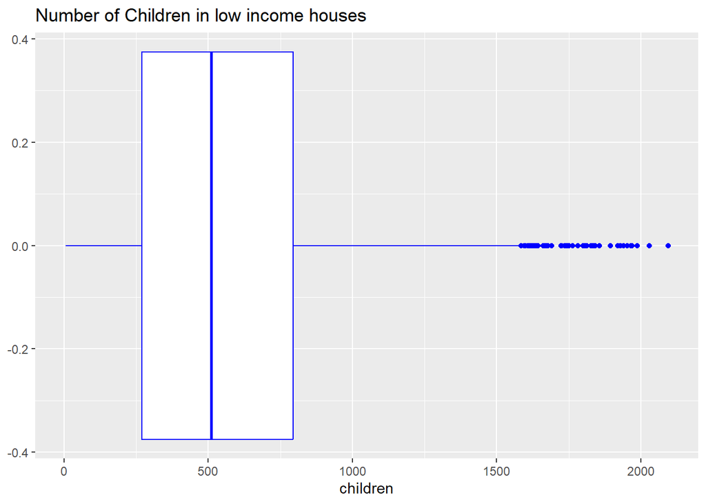

```r
library(ggplot2)

ggplot(dataset, aes(children))+ geom_boxplot(color = "blue") +
   labs(title = "Number of Children in low income houses")
```

The boxplot provides an initial view of the spread and skewness in the number of children recorded across wards and years.

## Borough-Level Summary Statistics

For grouping the boroughs we would use group_by followed by the conditions A. For finding average number of children in low income homes per ward across all years

```r
library(dplyr)

#make a new data set consisting of the average of children in low income homes by grouping the name of the Boroughs
dataset_avg <- dataset %>%
  group_by(Borough) %>%
  summarise(average = mean(children,na.rm = TRUE))
```

B. For finding standard deviation of children in low income homes per ward across all years

```r
#make a new data set consisting of the standard deviation of children in low income homes by grouping the name of the Boroughs
dataset_sd <- dataset %>%
  group_by(Borough) %>%
  summarise(StandardDeviation = sd(children, na.rm = TRUE))
```

C. For finding lowest number of children in low income homes for a ward in any year

```r
#make a new data set consisting of the lowest number of children in low income homes by grouping the name of the Boroughs
dataset_min <- dataset %>%
  group_by(Borough) %>%
  summarise(Minimum = min(children, na.rm = TRUE))
```

D. For finding highest number of children in low income homes for a ward in any year

```r
#make a new data set consisting of the highest number of children in low income homes by grouping the name of the Boroughs
dataset_max <- dataset %>%
  group_by(Borough) %>%
  summarise(Maximum = max(children, na.rm = TRUE))
```

After performing the above calculations,a new dataset of children in low income homes which consist of boroughs of London, the calculated average number, calculated standard deviation and calculated lowest and highest number is binded and renamed accordingly

```r
#make a new dataset with a table that includes average, standard deviation, minimum and maximum number of children in low income homes across all years
dataset_new <- bind_cols(dataset_avg,dataset_sd$StandardDeviation,dataset_min$Minimum,dataset_max$Maximum)
colnames(dataset_new) <- c(
  "Borough",
  "Average Children",
  "Standard Deviation",
  "Minimum",
  "Maximum"
)

dataset_new
```

```
## # A tibble: 33 × 5
##    Borough              `Average Children` `Standard Deviation` Minimum Maximum
##    <chr>                             <dbl>                <dbl>   <int>   <int>
##  1 Barking and Dagenham              987.                 259.      551    1750
##  2 Barnet                            588.                 340.      116    1807
##  3 Bexley                            506.                 246.      174    1469
##  4 Brent                             708.                 281.      249    1578
##  5 Bromley                           390.                 211.      113    1062
##  6 Camden                            452.                 268.       78    1373
##  7 City of London                     26.5                 31.8       5     156
##  8 Croydon                           570.                 315.       48    1508
##  9 Ealing                            640.                 314.      128    1327
## 10 Enfield                           738.                 409.      193    1895
## # ℹ 23 more rows
```

## Filtering Unusual Boroughs

```r
#make a new dataset by removing the unusual boroughs
dataset_final <- dataset_new %>%
  filter(Borough != "City of London", Borough !="Kensington and Chelsea", Borough !="Kingston upon Thames",Borough !="Richmond upon Thames", Borough !="Westminster" )
```

```r
data <- dataset %>%
  filter(dataset$Borough != "City of London" & dataset$Borough !="Kensington and Chelsea" & dataset$Borough !="Kingston upon Thames"& dataset$Borough !="Richmond upon Thames" & dataset$Borough !="Westminster")
```

## Yearly Distribution Analysis

```r
#install.packages("ggplot2")

#library(ggplot2)
```

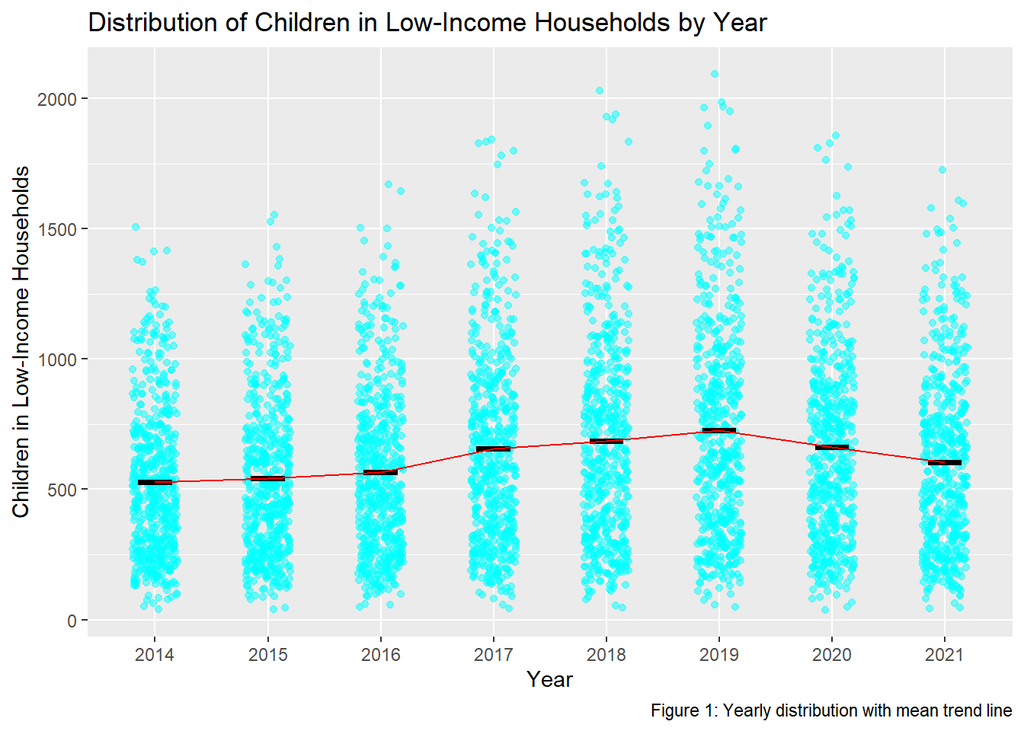

```r
#make a new dataset by removing the unusual boroughs
my_plot <- ggplot(data, aes(x = as.factor(year), y = children)) +
  geom_jitter(width = 0.2, alpha = 0.5, color = "cyan") +
  stat_summary(
    fun = mean,
    geom = "crossbar",
    width = 0.3,
    color = "black"
  ) +
  stat_summary(
    fun = mean,
    geom = "line",
    aes(group = 1),
    color = "red"
  ) +
  labs(
    title = "Distribution of Children in Low-Income Households by Year",
    x = "Year",
    y = "Children in Low-Income Households",
    caption = "Figure 1: Yearly distribution with mean trend line"
  )

my_plot
```

## Statistical Comparison: 2014 vs 2021

```r
# Filter data for the earliest year (2014)
data_2014 <- data %>% filter(year == 2014)

# Filter data for the latest year (2021)
data_2021 <- data %>% filter(year == 2021)
```

```r
# Perform a two-sample t-test

t.test(data_2014$children, data_2021$children, alternative = "two.sided")
```

```
##
##  Welch Two Sample t-test
##
## data:  data_2014$children and data_2021$children
## t = -4.0215, df = 1095.2, p-value = 6.18e-05
## alternative hypothesis: true difference in means is not equal to 0
## 95 percent confidence interval:
##  -112.4091  -38.6873
## sample estimates:
## mean of x mean of y
##  528.3214  603.8696
```

```r
t_test_result <- t.test(data_2014$children, data_2021$children, alternative = "two.sided")
```

After applying the t-test to the two sets of data about the number of children living in low-income housing in London in 2014 and 2021, the test statistics yielded a value of -4.0215, indicating a difference in the available data’s mean.

Null Hypothesis Significance Testing (NHST):

The NHST method determines whether an event is statistically significant or a random occurrence. Where H0 is the null hypothesis, stating no difference in statistical data, and Ha is the alternative hypothesis, contradicting the null hypothesis. To arrive at a solution, this method takes into account the computed p-value and t-value from the t-tests.

```r
# Report the results using Null Hypothesis Significance Testing (NHST)
#Display the Null Hypothesis
cat("Null Hypothesis Significance Testing (NHST):\n")
```

```
## Null Hypothesis Significance Testing (NHST):
```

```r
#Specifying the null hypothesis H0 and Ha to be an alternative hypothesis
cat("H0: The means of children in low-income households in 2014 and 2021 are equal.\n")
```

```
## H0: The means of children in low-income households in 2014 and 2021 are equal.
```

```r
cat("Ha: The means of children in low-income households in 2014 and 2021 are not equal.\n")
```

```
## Ha: The means of children in low-income households in 2014 and 2021 are not equal.
```

```r
# printing the statistical value
cat("t-value:", t_test_result$statistic, "\n")
```

```
## t-value: -4.021485
```

```r
#printing the probability value
cat("p-value:", t_test_result$p.value, "\n")
```

```
## p-value: 6.179676e-05
```

## Using the Estimation approach

```r
# Print the results using the estimation approach
cat("\nEstimation Approach:\n")
```

```
##
## Estimation Approach:
```

```r
#Print the confidence Interval
cat("95% Confidence Interval for the difference in means: [", t_test_result$conf.int[1], ", ", t_test_result$conf.int[2], "]\n")
```

```
## 95% Confidence Interval for the difference in means: [ -112.4091 ,  -38.6873 ]
```

The estimation approach is based on the hypothesis testing performed on the data which provides the size of the data set.

```r
# To determine the significance, check if the p-value is smaller than the significance level.
if (t_test_result$p.value < 0.05) {
  cat("\nThe difference in means is statistically significant at the 0.05 significance level.\n")
} else {
  cat("\nThe difference in means is not statistically significant at the 0.05 significance level.\n")
}
```

```
##
## The difference in means is statistically significant at the 0.05 significance level.
```

## Insights and Interpretation

This analysis shows how the number of children living in low-income households varied across London boroughs between 2014 and 2021. Boroughs with unusually small counts were excluded to ensure a more meaningful comparison across the remaining boroughs.

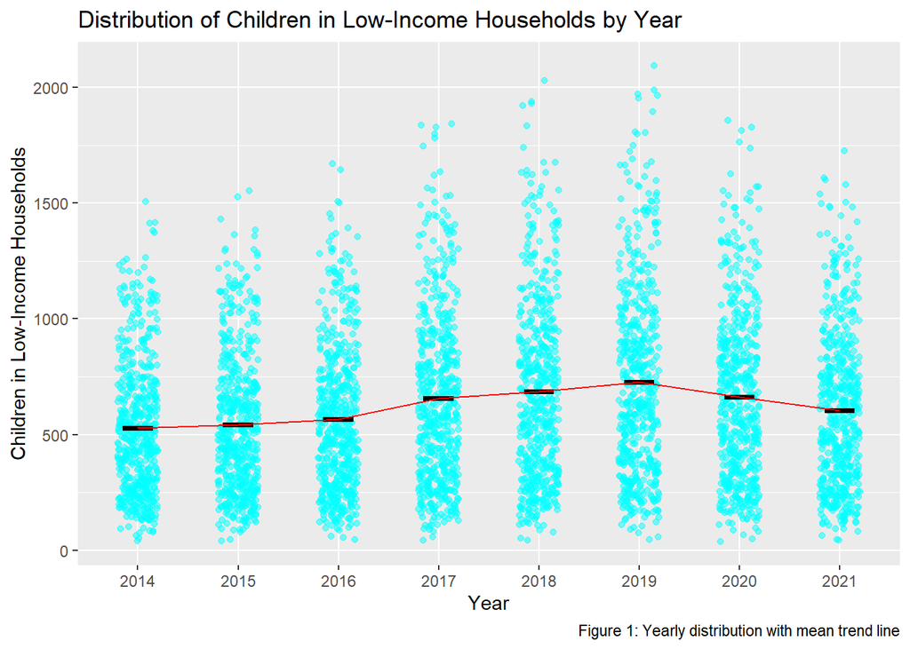

```r
my_plot
```

The statistical test indicates a significant difference between 2014 and 2021. The mean number of children in low-income households was higher in 2021 than in 2014, suggesting an upward shift over the analysed period.